# Business Analytics Case Study - Fitness Mobile App

By Ishack Mougamadou

The probability of a customer willing to pay for a fitness app is defined by the following factors, income, number of gym visits and hours spent at the gym. This analysis was done to identify the most significant factor that influences whether a customer would pay for a mobile fitness app.

This analysis was run on R Studio Version 1.1.456: Windows 10 Intel i3 4GB RAM

# Load Libraries

```r
library(rpart) # Decision Tree library
```

# Explanatory Data Analysis

```r
fitness= read.csv("Fitness_App_Log.csv") # import the csv
fitness
```

| Incomes | GymVisits | State | Hours | PayOrNot |
| --- | --- | --- | --- | --- |
| 100 | 4 | TX | 9.3 | Yes |
| 50 | 3 | CA | 4.8 | No |
| 100 | 4 | TX | 8.9 | Yes |
| 100 | 2 | NY | 6.5 | Yes |
| 50 | 2 | MD | 4.2 | No |
| 80 | 2 | CA | 6.2 | No |
| 75 | 3 | WA | 7.4 | No |
| 65 | 4 | SD | 6.0 | No |
| 90 | 3 | ND | 7.6 | Yes |
| 90 | 2 | TX | 6.1 | No |

[output cut: 90 more lines]

```r
str(fitness) # the characteristics of the dataset.
```

```
## 'data.frame':    100 obs. of  5 variables:
##  $ Incomes  : int  100 50 100 100 50 80 75 65 90 90 ...
##  $ GymVisits: int  4 3 4 2 2 2 3 4 3 2 ...
##  $ State    : Factor w/ 7 levels "CA","MD","ND",..: 6 1 6 4 2 1 7 5 3 6 ...
##  $ Hours    : num  9.3 4.8 8.9 6.5 4.2 6.2 7.4 6 7.6 6.1 ...
##  $ PayOrNot : Factor w/ 2 levels "No","Yes": 2 1 2 2 1 1 1 1 2 1 ...
```

```r
attach(fitness) # attach each of the variables to a variable name
```

```r
summary(fitness) # summary of the dataset
```

```
##     Incomes        GymVisits    State       Hours      PayOrNot
##  Min.   : 40.0   Min.   :0.00   CA:20   Min.   :4.20   No :72
##  1st Qu.: 65.0   1st Qu.:2.00   MD:10   1st Qu.:6.00   Yes:28
##  Median : 80.0   Median :3.00   ND:10   Median :6.35
##  Mean   : 79.4   Mean   :2.98   NY:10   Mean   :6.70
##  3rd Qu.:100.0   3rd Qu.:4.00   SD:10   3rd Qu.:7.60
##  Max.   :100.0   Max.   :7.00   TX:30   Max.   :9.30
##                                 WA:10
```

# Frequency Distribution Graphs

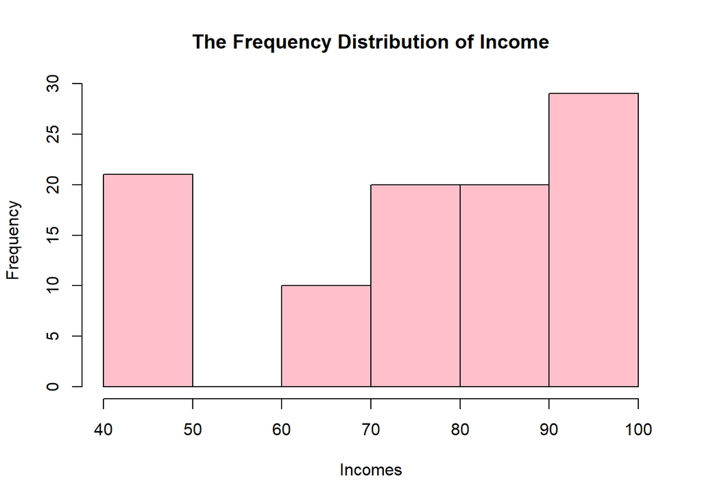

```r
#Created a frequency distribution graph for each of the numeric variables.
hist(Incomes, col = "Pink", main="The Frequency Distribution of Income") # Income
```

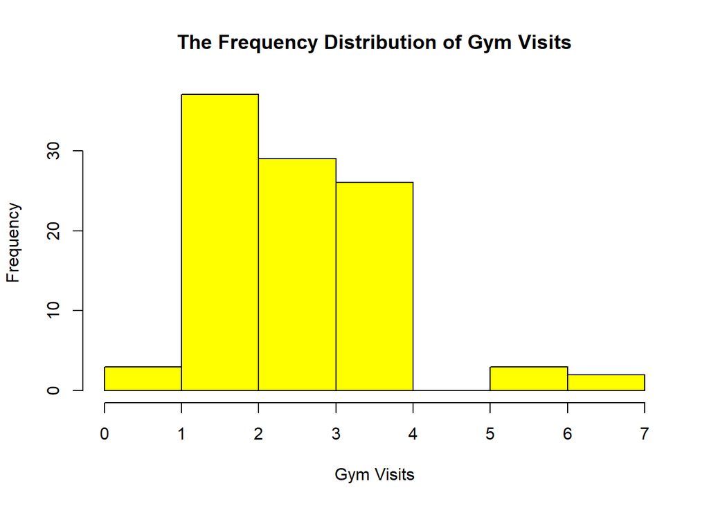

```r
hist(GymVisits, col = "yellow",xlab = "Gym Visits", main="The Frequency Distribution of Gym Visits") # Gym Visits
```

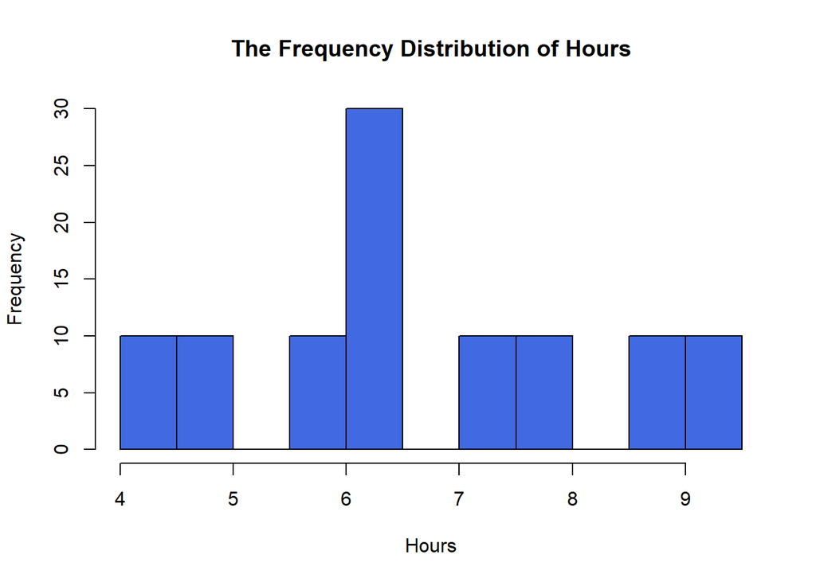

```r
hist(Hours, col = "royalblue", main="The Frequency Distribution of Hours") # Hours
```

All the factors showed that the residuals are non-normally distributed.

# Diagnostic plots

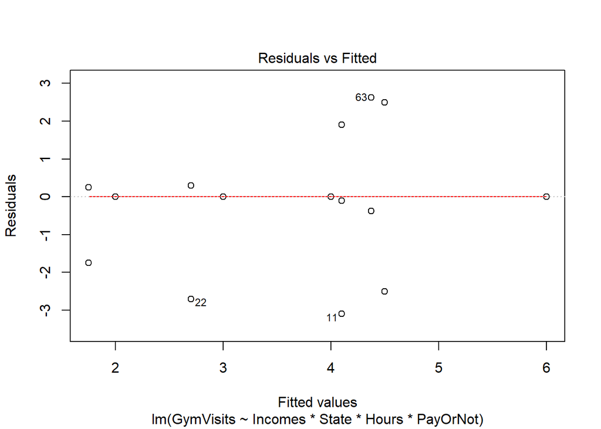

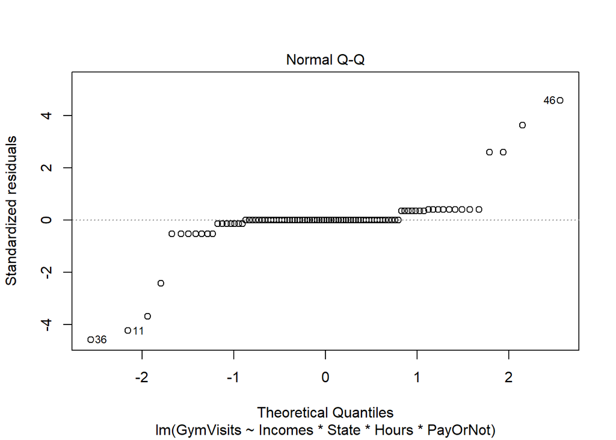

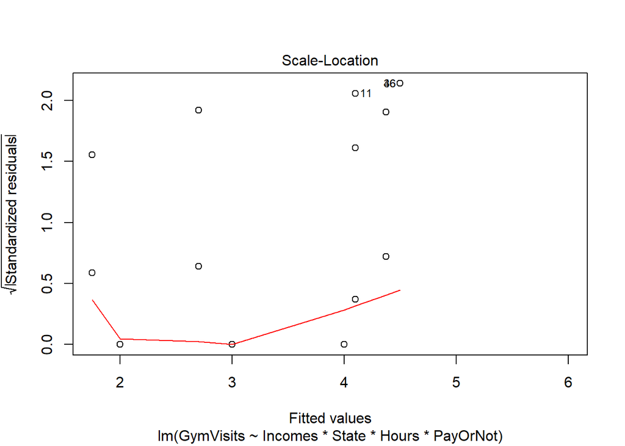

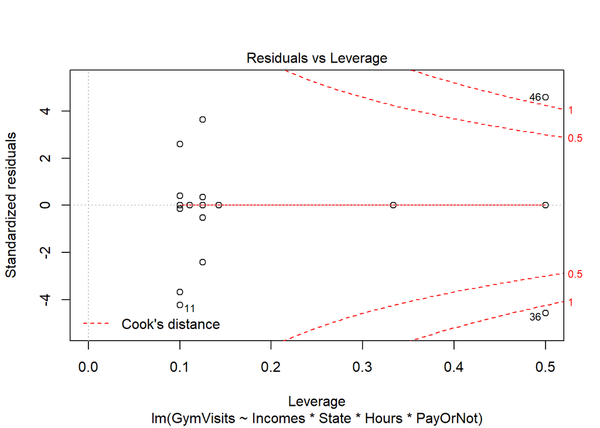

```r
diagnostic_plot=lm(GymVisits~Incomes*State*Hours*PayOrNot) # Diagnostic plot
plot(diagnostic_plot) # plot the diagnostic plots
```

```r
shapiro.test(Incomes) # Normality test
```

```
##
##  Shapiro-Wilk normality test
##
## data:  Incomes
## W = 0.85629, p-value = 2.039e-08
```

P-value confirmed that the residuals are non-normally distrubuted.

# Boxplot

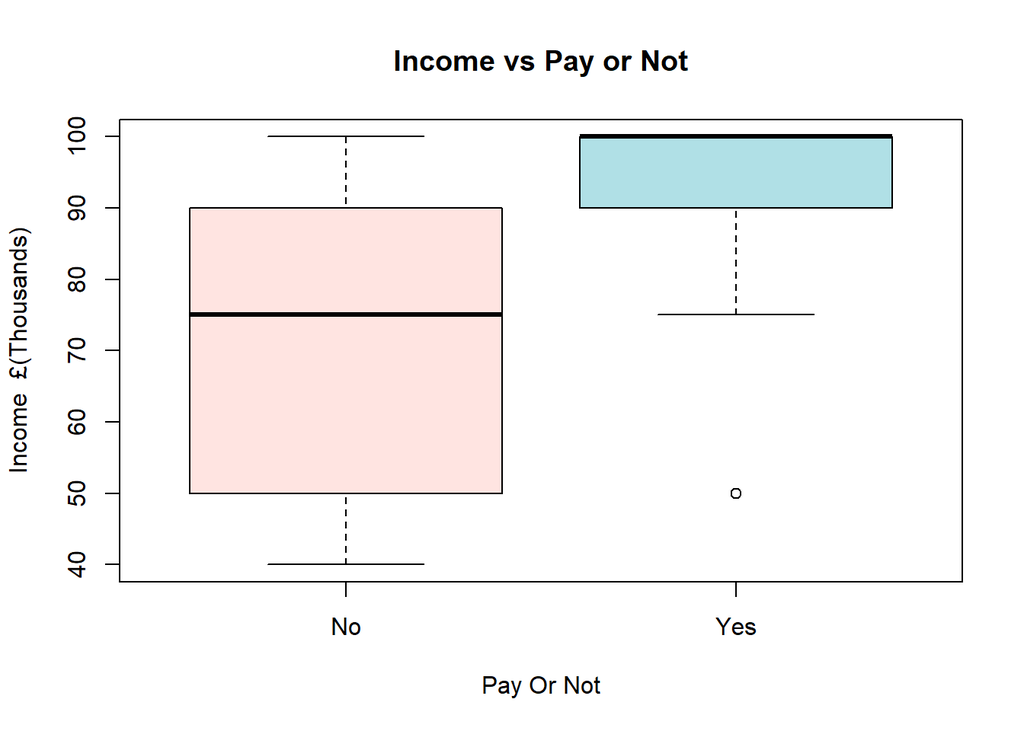

```r
boxplot(Incomes~PayOrNot, col=c("mistyrose","powderblue"),
        main="Income vs Pay or Not", ylab="Income  £(Thousands)", xlab="Pay Or Not")  # Boxplot of Pay Status based on Income
```

# Correlations Plots

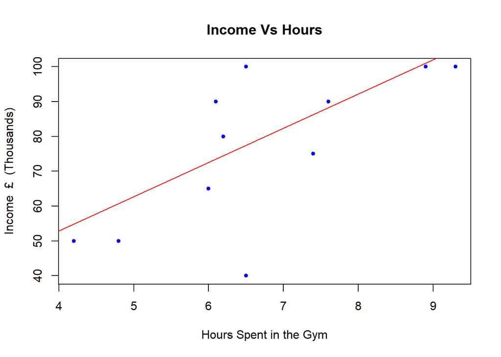

```r
# Income vs Hours
model_income=(Incomes~Hours)
plot(model_income, pch = 20, col= "blue", main= "Income Vs Hours", ylab = "Income  £  (Thousands)", xlab= "Hours Spent in the Gym")
abline (lm(model_income), col="red")
```

There was a positive relationship between the income and the hours spent at the gym.

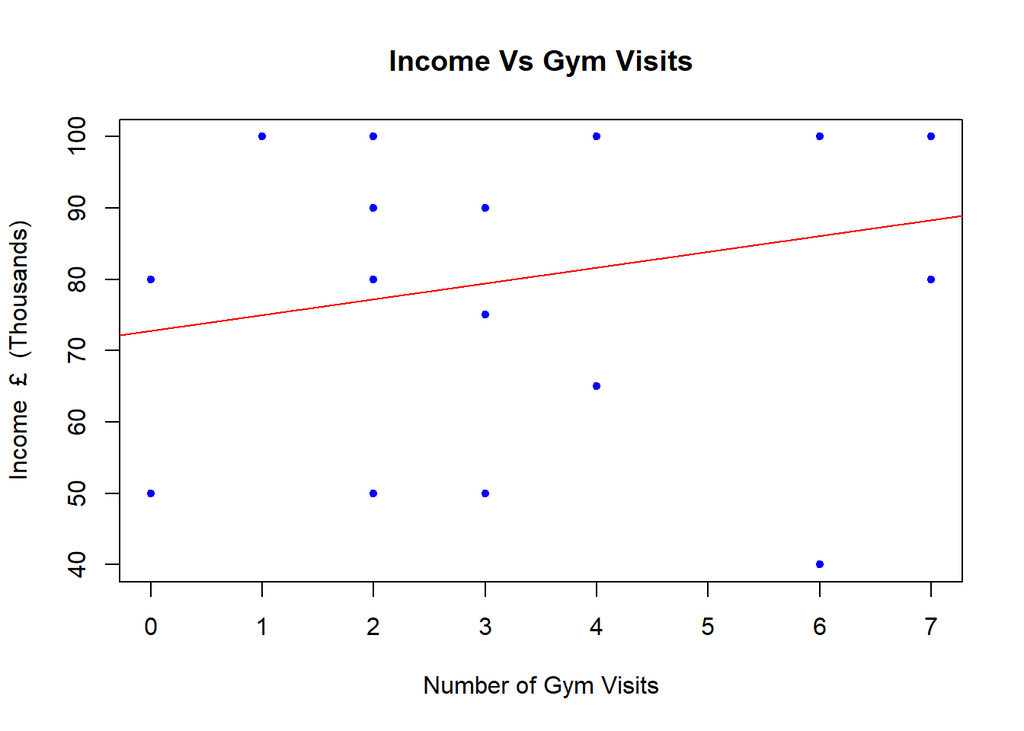

```r
# Income vs Gym Visits
model1=(Incomes~GymVisits)
plot(model1, pch = 20, col= "blue", main= "Income Vs Gym Visits", ylab = "Income  £  (Thousands)", xlab= "Number of Gym Visits")
abline (lm(model1), col="red")
```

There was a positive relationship between the income and the number of visits to the gym.

# Pearson Correlation Tests

```r
# Pearson correlation between income and fitness visits
cor.test(Incomes,GymVisits, method = "pearson")
```

```
##
##  Pearson's product-moment correlation
##
## data:  Incomes and GymVisits
## t = 1.4068, df = 98, p-value = 0.1626
## alternative hypothesis: true correlation is not equal to 0
## 95 percent confidence interval:
##  -0.05730557  0.32804860
## sample estimates:
##       cor
## 0.1406962
```

There was no statistically significant difference between the income and the number of gym visits.

```r
cor.test(Incomes,Hours, method = "pearson")
```

```
##
##  Pearson's product-moment correlation
##
## data:  Incomes and Hours
## t = 13.461, df = 98, p-value < 2.2e-16
## alternative hypothesis: true correlation is not equal to 0
## 95 percent confidence interval:
##  0.7237052 0.8651306
## sample estimates:
##       cor
## 0.8056072
```

However,there was a statistically significant difference between the income and the number of hours spent at the gym (P-value = < 2.2e-16).

# ANOVA Analysis

```r
anova_model=lm(Incomes~GymVisits*Hours*PayOrNot)
anova1=anova(anova_model)
anova1
```

|  | Df | Sum Sq | Mean Sq | F value | Pr(>F) |
| --- | --- | --- | --- | --- | --- |
| GymVisits | 1 | 7.059839e+02 | 7.059839e+02 | 1.091383e+01 | 1.360826e-03 |
| Hours | 1 | 2.555862e+04 | 2.555862e+04 | 3.951116e+02 | 4.640687e-35 |
| PayOrNot | 1 | 1.689463e-01 | 1.689463e-01 | 2.611747e-03 | 9.593524e-01 |
| GymVisits:Hours | 1 | 9.788099e+00 | 9.788099e+00 | 1.513146e-01 | 6.981811e-01 |
| GymVisits:PayOrNot | 1 | 1.866087e+03 | 1.866087e+03 | 2.884790e+01 | 5.854553e-07 |
| Hours:PayOrNot | 1 | 8.890979e+02 | 8.890979e+02 | 1.374460e+01 | 3.576713e-04 |
| GymVisits:Hours:PayOrNot | 1 | 6.830454e+02 | 6.830454e+02 | 1.055922e+01 | 1.615251e-03 |
| Residuals | 92 | 5.951212e+03 | 6.468709e+01 | NA | NA |

# Decision Tree Analysis

```r
Tree_analysis= rpart(PayOrNot~Incomes+GymVisits+State,data = fitness) # Decision Tree model
Tree_analysis
```

```
## n= 100
##
## node), split, n, loss, yval, (yprob)
##       * denotes terminal node
##
## 1) root 100 28 No (0.7200000 0.2800000)
##   2) Incomes< 95 71  9 No (0.8732394 0.1267606) *
##   3) Incomes>=95 29 10 Yes (0.3448276 0.6551724)
##     6) State=NY 9  1 No (0.8888889 0.1111111) *
##     7) State=TX 20  2 Yes (0.1000000 0.9000000) *
```

```r
#install.packages("rpart.plot") # package for decision plot
```

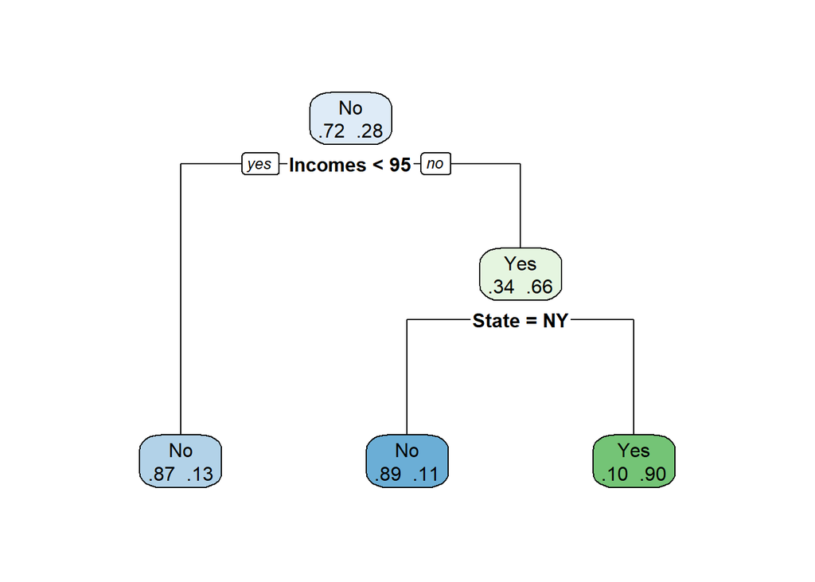

```r
library("rpart.plot") # for the decision tree plot
DT=rpart.plot(Tree_analysis,extra = 4)
```

The decision tree analysis indicated that income influenced the customer’s decision the most. Also, the state where they lived also played a vital role in the decision-making process.

# Random Forest

```r
#install.packages("randomForest")
```

```r
library(randomForest)
RF<- randomForest( PayOrNot~ Incomes + GymVisits + Hours, data = fitness)
```

```r
print(RF)
```

```
##
## Call:
##  randomForest(formula = PayOrNot ~ Incomes + GymVisits + Hours,      data = fitness)
##                Type of random forest: classification
##                      Number of trees: 500
## No. of variables tried at each split: 1
##
##         OOB estimate of  error rate: 12%
## Confusion matrix:
##     No Yes class.error
## No  70   2  0.02777778
## Yes 10  18  0.35714286
```

```r
print(importance(RF,type = 2))
```

```
##           MeanDecreaseGini
## Incomes           6.493895
## GymVisits         5.603662
## Hours            10.538482
```

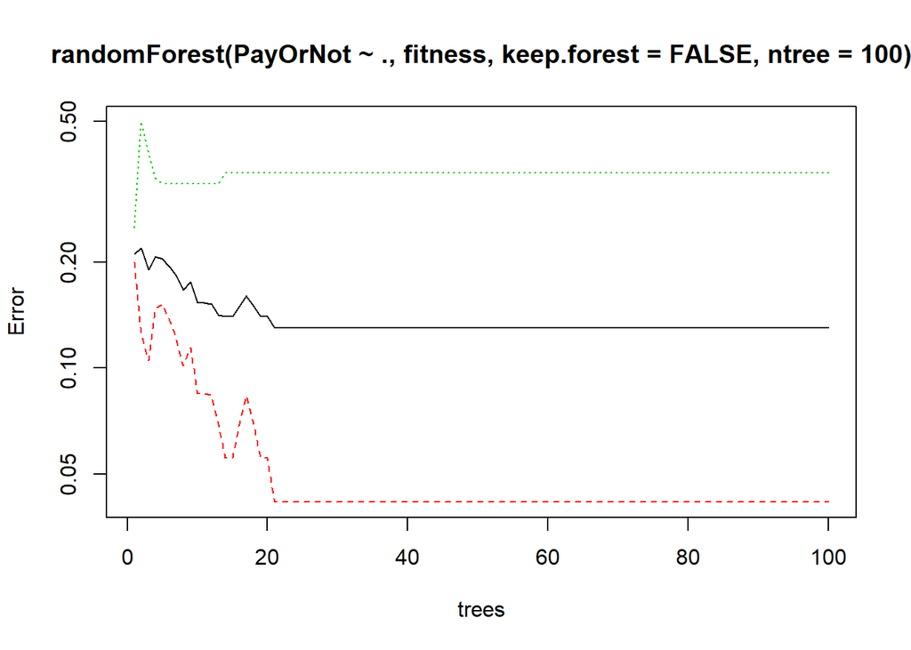

```r
plot(randomForest(PayOrNot ~ ., fitness, keep.forest=FALSE, ntree=100), log="y")
```

```r
# the bigger the mean decrease, the better
```

# Logistic Regression

```r
LR = glm(formula = PayOrNot ~ Incomes + Hours + GymVisits, data = fitness, family = binomial)
print(summary(LR))
```

```
##
## Call:
## glm(formula = PayOrNot ~ Incomes + Hours + GymVisits, family = binomial,
##     data = fitness)
##
## Deviance Residuals:
##     Min       1Q   Median       3Q      Max
## -1.8621  -0.5894  -0.3875   0.3787   3.2796
##
## Coefficients:
##              Estimate Std. Error z value Pr(>|z|)
## (Intercept) -11.84369    2.42446  -4.885 1.03e-06 ***
## Incomes       0.03510    0.03132   1.121   0.2625
## Hours         0.88458    0.37417   2.364   0.0181 *
## GymVisits     0.50017    0.31702   1.578   0.1146
## ---
## Signif. codes:  0 '***' 0.001 '**' 0.01 '*' 0.05 '.' 0.1 ' ' 1
##
## (Dispersion parameter for binomial family taken to be 1)
##
##     Null deviance: 118.591  on 99  degrees of freedom
## Residual deviance:  69.841  on 96  degrees of freedom
## AIC: 77.841
##
## Number of Fisher Scoring iterations: 6
```

```r
# discrite varaibles
```